# Analyze_ab_test_results_notebook

## Analyze A/B Test Results

- Introduction
- Part I - Probability
- Part II - A/B Test
- Part III - Regression

### Introduction

For this project, I will perform an A/B test for an e-commerce website. The goal is to help the company understand if they should implement the new page, keep the old page, or perhaps run the experiment longer to make their decision.

#### `1`. Wrangling

```python
import pandas as pd
import numpy as np
import random
import seaborn as sb
import matplotlib.pyplot as plt
%matplotlib inline
#We are setting the seed to assure you get the same answers on quizzes as we set up
random.seed(42)
```

- Read in the `ab_data.csv` data.

```python
df = pd.read_csv("ab_data.csv")
df.head(3)
```

|  | user_id | timestamp | group | landing_page | converted |
| --- | --- | --- | --- | --- | --- |
| 0 | 851104 | 2017-01-21 22:11:48.556739 | control | old_page | 0 |
| 1 | 804228 | 2017-01-12 08:01:45.159739 | control | old_page | 0 |
| 2 | 661590 | 2017-01-11 16:55:06.154213 | treatment | new_page | 0 |

a. View the general info

```python
df.info()
```

```
<class 'pandas.core.frame.DataFrame'>
RangeIndex: 294478 entries, 0 to 294477
Data columns (total 5 columns):
 #   Column        Non-Null Count   Dtype
---  ------        --------------   -----
 0   user_id       294478 non-null  int64
 1   timestamp     294478 non-null  object
 2   group         294478 non-null  object
 3   landing_page  294478 non-null  object
 4   converted     294478 non-null  int64
dtypes: int64(2), object(3)
memory usage: 11.2+ MB
```

```python
df.timestamp = pd.to_datetime(df.timestamp)
```

```python
df.duplicated().sum()
```

```
0
```

> **There is no missing, no duplicate**

b. The number of rows in the dataset.

```python
n = df.shape[0]
n
```

```
294478
```

c. The number of unique users in the dataset.

```python
n_user1 = df.user_id.nunique()
n_user1
```

```
290584
```

d. The proportion of users converted.

```python
p_converted = df.query('converted == 1').count()[0]/n
p_converted
```

```
0.11965919355605512
```

e. Check the non-matching data: (the `new_page` and `treatment` don't match)

```python
df.query("group == 'treatment' & landing_page == 'old_page' or group == 'control' & landing_page == 'new_page'").count()[0]
```

```
3893
```

#### `2.` Cleaning:

a. Remove the confusing data, which are, the rows where **treatment** does not match with **new_page** and **control** does not match with **old_page**

```python
df2 = df.drop(df.query("group == 'treatment' & landing_page != 'new_page' or group == 'control' & landing_page != 'old_page'").index)
```

```python
# Double Check all of the correct rows were removed - this should be 0
df2[((df2['group'] == 'treatment') == (df2['landing_page'] == 'new_page')) == False].shape[0]
```

```
0
```

```python
n_user2 = df2.user_id.nunique()
n_user2, df2.count()[0]
```

```
(290584, 290585)
```

```python
# There is one duplcated user_id --> View it
dup = df2[df2.user_id.duplicated()]
dup["user_id"]
```

```python
dup
```

|  | user_id | timestamp | group | landing_page | converted |
| --- | --- | --- | --- | --- | --- |
| 2893 | 773192 | 2017-01-14 02:55:59.590927 | treatment | new_page | 0 |

#### `3` First analysing numbers

a. The proportion of new_page and old page

```python
df2.groupby("landing_page").count()
```

| landing_page | user_id | timestamp | group | converted |
| --- | --- | --- | --- | --- |
| new_page | 145310 | 145310 | 145310 | 145310 |
| old_page | 145274 | 145274 | 145274 | 145274 |

b. The conversion probability in general, regardless of the page they receive

```python
p_converted = df2["converted"].mean()
p_converted
```

```
0.11959708724499628
```

c. The conversion probability of the `control` group

```python
p_old_converted = df2.query('group == "control"')["converted"].mean()
p_old_converted
```

```
0.1203863045004612
```

d. The conversion probability of the `treatment` group

```python
p_new_converted = df2.query('group == "treatment"')["converted"].mean()
p_new_converted
```

```
0.11880806551510564
```

e. The probability that an individual received the new page

```python
p_new_page = df2.query('landing_page == "new_page"').count()[0]/df2.count()[0]
p_new_page
```

```
0.5000619442226688
```

f. If the new page receive more conversion than the old page ?

```python
obs_diff = p_new_converted - p_old_converted
obs_diff
```

```
-0.0015782389853555567
```

### Part II - A/B Test

`1.` Consider Type I error rate of 5%, based on all the data provided, this test will try to find out if there is significant evidence to conclure that the new page is better than the old one (that means the new page is efficient) ? To do that, let's start with a hypothesis ($H_{0}$) which is the reverse belief - the new page is worst than the old one

- $H_{0}$: $p_{new}$ - $p_{old}$ <= 0
- $H_{1}$: $p_{new}$ - $p_{old}$ > 0

`2.` Steps:

- Assume under the null hypothesis, $p_{new}$ and $p_{old}$ both have "true" success rates equal to the **converted** success rate regardless of page - that is $p_{new}$ and $p_{old}$ are equal. Furthermore, assume they are equal to the **converted** rate in **ab_data.csv** regardless of the page.
- Use a sample size for each page equal to the ones in **ab_data.csv**.
- Perform the sampling distribution for the difference in **converted** between the two pages over 10,000 iterations of calculating an estimate from the null.

a. The **conversion rate** for $p_{new}$ under the null

```python
# null: p_new = p_old = p_converted (regarless which page)
p_new = p_converted
```

b. The **conversion rate** for $p_{old}$ under the null?

```python
p_old = p_new
p_old
```

```
0.11959708724499628
```

c. Calculate $n_{new}$, the number of individuals in the treatment group

```python
n_new = df2.query('group == "treatment"').count()[0]
n_new
```

```
145310
```

d. Calculate $n_{old}$, the number of individuals in the control group

```python
n_old = df2.query('group == "control"').count()[0]
n_old
```

```
145274
```

e. Simulate $n_{new}$ transactions with a conversion rate of $p_{new}$ under the null. Store these $n_{new}$ 1's and 0's in **new_page_converted**.

```python
new_page_converted = np.random.binomial(1, p_new, n_new)
new_page_converted
```

```
array([0, 0, 0, ..., 0, 0, 0])
```

f. Simulate $n_{old}$ transactions with a conversion rate of $p_{old}$ under the null. Store these $n_{old}$ 1's and 0's in **old_page_converted**.

```python
old_page_converted = np.random.binomial(1, p_old, n_old)
old_page_converted
```

```
array([0, 0, 0, ..., 0, 0, 0])
```

g. Find $p_{new}$ - $p_{old}$ for the simulated values later.

```python
simulated_diff = (new_page_converted).mean() - (old_page_converted).mean()
simulated_diff
```

```
-0.0013854247114132023
```

h. Create 10,000 $p_{new}$ - $p_{old}$ values using the same simulation process above. Store all 10,000 values in **p_diffs**.

```python
p_diffs = []
olds = []
news = []
for _ in range(10000):
    new_page = np.random.binomial(1, p_new, n_new)
    old_page = np.random.binomial(1, p_old, n_old)
    olds.append(old_page.mean()), news.append(new_page.mean())
    p_diffs.append(new_page.mean() - old_page.mean())
```

i. Plot a histogram of the **p_diffs**.

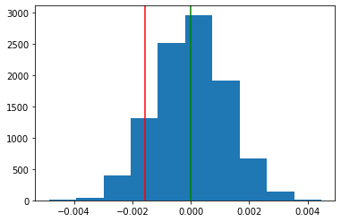

```python
plt.hist(p_diffs)
plt.axvline(x = obs_diff, color = 'red')
plt.axvline(x = np.mean(p_diffs), color = 'green');
```

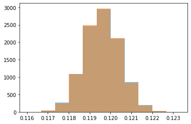

```python
plt.hist(news, alpha = 0.5)
plt.hist(olds, alpha = 0.3);
```

> **Almost observed samples are fall into the null hypothesis. It seems I can not reject the null hypothesis, but before, let's see the condifence p_value**

```python
p_value = (p_diffs < obs_diff).mean()
p_value
```

[output not shown]

l. Now, compare this result with the built-in function stats in Python

```python
import statsmodels.api as sm

convert_old = df2.query('group == "control" & converted == 1').shape[0]
convert_new = df2.query('group == "treatment" & converted == 1').shape[0]
#n_old = df2.query('group == "control"').count()[0]
#n_new = df2.query('group == "treatment"').count()[0]
n_old, n_new, convert_old, convert_new
```

```
(145274, 145310, 17489, 17264)
```

m. Compute the test statistic and p-value using `stats.proportions_ztest`

```python
z_score, p_value = sm.stats.proportions_ztest((convert_new, convert_old), (n_new, n_old))
z_score, p_value
```

```
(-1.3109241984234394, 0.18988337448195103)
```

```python
z_score1, p_value1 = sm.stats.proportions_ztest((convert_new, convert_old), (n_new, n_old), alternative = 'larger')
z_score1, p_value1
```

```
(-1.3109241984234394, 0.9050583127590245)
```

k. Explain the meaning of z_score and p_value

> - Z-score is measure of standard deviation and p-value is probabilities of rejecting the null hypothesis. Practically, a very high or a very low (negative) Z-score demonstrates that almost observations are far from the 95% confidence interval of the null-hypothesis. That means, it associates with a very small p-value and indicates that there is no evidence to support the null hypothesis.

| z-score (Standard Deviations) | p-value (Probability) | Confidence level |
| --- | --- | --- |
| < -1.65 or > +1.65 | < 0.10 | 90% |
| < -1.96 or > +1.96 | < 0.05 | 95% |
| < -2.58 or > +2.58 | < 0.01 | 99% |

### Part III - A regression approach

`1.` In this final part, I try to see if the result achieved in the A/B test in Part II above can also be achieved by performing regression. Since there is 2 labels, the **logistic regression** seems good fit.

```python
df2['intercept'] = 1
# use one hot encoding for categorical feature
df2['ab_page'] = pd.get_dummies(df2.group)["treatment"]
```

```python
df2.head(2)
```

|  | user_id | timestamp | group | landing_page | converted | intercept | ab_page |
| --- | --- | --- | --- | --- | --- | --- | --- |
| 0 | 851104 | 2017-01-21 22:11:48.556739 | control | old_page | 0 | 1 | 0 |
| 1 | 804228 | 2017-01-12 08:01:45.159739 | control | old_page | 0 | 1 | 0 |

b. Use **statsmodels** to instantiate the regression model on the two columns above

```python
import statsmodels.api as sm
logit_mod = sm.Logit(df2['converted'], df2[['intercept', 'ab_page']])
results = logit_mod.fit();
```

```
Optimization terminated successfully.
         Current function value: 0.366118
         Iterations 6
```

d. Summary of the model:

```python
results.summary()
```

Logit Regression Results

| Dep. Variable: | converted | No. Observations: | 290584 |
| --- | --- | --- | --- |
| Model: | Logit | Df Residuals: | 290582 |
| Method: | MLE | Df Model: | 1 |
| Date: | Thu, 21 May 2020 | Pseudo R-squ.: | 8.077e-06 |
| Time: | 11:07:51 | Log-Likelihood: | -1.0639e+05 |
| converged: | True | LL-Null: | -1.0639e+05 |
| Covariance Type: | nonrobust | LLR p-value: | 0.1899 |

|  | coef | std err | z | P>\|z\| | [0.025 | 0.975] |
| --- | --- | --- | --- | --- | --- | --- |
| intercept | -1.9888 | 0.008 | -246.669 | 0.000 | -2.005 | -1.973 |
| ab_page | -0.0150 | 0.011 | -1.311 | 0.190 | -0.037 | 0.007 |

```python
np.exp(results.params)
```

```
intercept    0.136863
ab_page      0.985123
dtype: float64
```

> Regarding to this statistic, the new page and the old page are the same (ratio ~ 1) in term of their effectiveness to the conversion\ \ The p-value associated with ab_page is 0.190, this differs from Part II as the test for Part II. Reason: The alternative hyphothesis from part II is the greater case (p_new - p_old > 0) while the alternative hyphothesis in this regression is on 2-sides (p_new < > p_old)\ \ Other ideas to analyse this data and perform the A/Btesting:
> - It could be a good idea if we consider other factors (Ex: time staying on the plafform, etc.) as they give us diffrents view to verify and avoid the bias. However, we can pay attention on the numbers of tests, because, as my understanding, the more tests are taken, the less they are trustable. Although we have the regulisation, some test conlicting the other ones might cause the prediction less accurate (Please help to verify)**

g. Now, add an effect based on which country a user lives in. Does it appear that country had an impact on conversion? The additional data is taken from the **countries.csv** dataset.

```python
# Load the dataset
countries = pd.read_csv("countries.csv")
countries.head(2)
```

|  | user_id | country |
| --- | --- | --- |
| 0 | 834778 | UK |
| 1 | 928468 | US |

```python
# count the values
countries.groupby("country").count()
```

| country | user_id |
| --- | --- |
| CA | 14499 |
| UK | 72466 |
| US | 203619 |

```python
# verify if they have the same number of lines
df2.count()[0], countries.count()[0]
```

```
(290584, 290584)
```

```python
# join with the current dataset df2
df2 = df2.join(countries.set_index('user_id'), on='user_id')
```

```python
# one hot encoding
df2[['CA','UK','US']] = pd.get_dummies(df2['country'])
```

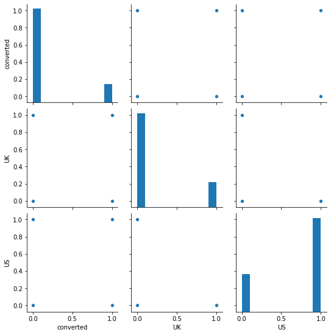

```python
# Visualize the relationship
sb.pairplot(df2[['converted','UK', 'US']].iloc[:200,]);
```

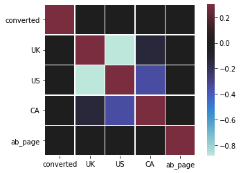

```python
corr = df2[['converted','UK', 'US', 'CA', 'ab_page']].corr()
sb.heatmap(corr, vmax=.3, center=0,
            square=True, linewidths=.5)
```

> **At a glance, it seems country, ab_page separately doesn't impact the conversion. Let's verify**

```python
# new page and country
lg = sm.Logit(df2['converted'], df2[['intercept','ab_page', 'US', 'UK']])
result = lg.fit()
```

```
Optimization terminated successfully.
         Current function value: 0.366113
         Iterations 6
```

```python
result.summary()
```

Logit Regression Results

| Dep. Variable: | converted | No. Observations: | 290584 |
| --- | --- | --- | --- |
| Model: | Logit | Df Residuals: | 290580 |
| Method: | MLE | Df Model: | 3 |
| Date: | Thu, 21 May 2020 | Pseudo R-squ.: | 2.323e-05 |
| Time: | 11:10:44 | Log-Likelihood: | -1.0639e+05 |
| converged: | True | LL-Null: | -1.0639e+05 |
| Covariance Type: | nonrobust | LLR p-value: | 0.1760 |

|  | coef | std err | z | P>\|z\| | [0.025 | 0.975] |
| --- | --- | --- | --- | --- | --- | --- |
| intercept | -2.0300 | 0.027 | -76.249 | 0.000 | -2.082 | -1.978 |
| ab_page | -0.0149 | 0.011 | -1.307 | 0.191 | -0.037 | 0.007 |
| US | 0.0408 | 0.027 | 1.516 | 0.130 | -0.012 | 0.093 |
| UK | 0.0506 | 0.028 | 1.784 | 0.074 | -0.005 | 0.106 |

```python
#reverse the result
np.exp(result.params)
```

```
intercept    0.131332
ab_page      0.985168
US           1.041599
UK           1.051944
dtype: float64
```

> - **These statistics are not significant as the p_value is too high (0.13 and 0.074 > 0.05) ==> This single country feature is not for fitting**

h. Now, instead of investigate the correlation of each single country with the conversion rate, I like to look at an interaction between page and country to see if there significant effects on conversion.

```python
# Create new feature for the new page by country
df2['ab_page_UK'] = df2['ab_page'] * df2['UK']
df2['ab_page_US'] = df2['ab_page'] * df2['US']
df2['ab_page_CA'] = df2['ab_page'] * df2['CA']
```

```python
lg1 = sm.Logit(df2['converted'], df2[['intercept', 'ab_page_UK', 'ab_page_US']])
lg2 = sm.Logit(df2['converted'], df2[['intercept', 'ab_page_UK', 'ab_page_CA']])
result1 = lg1.fit()
result2 = lg2.fit()
```

```
Optimization terminated successfully.
         Current function value: 0.366117
         Iterations 6
Optimization terminated successfully.
         Current function value: 0.366113
         Iterations 6
```

```python
result1.summary(), result2.summary()
```

```
(<class 'statsmodels.iolib.summary.Summary'>
 """
                            Logit Regression Results
 ==============================================================================
 Dep. Variable:              converted   No. Observations:               290584
 Model:                          Logit   Df Residuals:                   290581
 Method:                           MLE   Df Model:                            2
 Date:                Thu, 21 May 2020   Pseudo R-squ.:               1.082e-05
 Time:                        11:37:31   Log-Likelihood:            -1.0639e+05
 converged:                       True   LL-Null:                   -1.0639e+05
 Covariance Type:            nonrobust   LLR p-value:                    0.3164
 ==============================================================================
                  coef    std err          z      P>|z|      [0.025      0.975]
 ------------------------------------------------------------------------------
 intercept     -1.9926      0.008   -252.910      0.000      -2.008      -1.977
 ab_page_UK     0.0112      0.018      0.626      0.532      -0.024       0.046
 ab_page_US    -0.0144      0.012     -1.155      0.248      -0.039       0.010
 ==============================================================================
 """,
 <class 'statsmodels.iolib.summary.Summary'>
 """
                            Logit Regression Results
 ==============================================================================
 Dep. Variable:              converted   No. Observations:               290584
 Model:                          Logit   Df Residuals:                   290581
 Method:                           MLE   Df Model:                            2
 Date:                Thu, 21 May 2020   Pseudo R-squ.:               2.364e-05
 Time:                        11:37:33   Log-Likelihood:            -1.0639e+05
 converged:                       True   LL-Null:                   -1.0639e+05
 Covariance Type:            nonrobust   LLR p-value:                   0.08085
 ==============================================================================
                  coef    std err          z      P>|z|      [0.025      0.975]
 ------------------------------------------------------------------------------
 intercept     -1.9963      0.006   -322.049      0.000      -2.008      -1.984
 ab_page_UK     0.0149      0.017      0.862      0.389      -0.019       0.049
 ab_page_CA    -0.0752      0.038     -1.997      0.046      -0.149      -0.001
 ==============================================================================
 """)
```

> **It can be seen that there is slightly interaction of CA and the new page (p_value = 0,046)**

```python
np.exp(result3.params)
```

[output not shown]

[output not shown]

```python
print(1/0.919292)
```

```
1.0877936498957894
```

```python
from subprocess import call
call(['python', '-m', 'nbconvert', 'Analyze_ab_test_results_notebook.ipynb'])
```

```
0
```